# Amazon Fine Food Reviews — NLP & Text Analytics

Positive vs. Negative Sentiment Deep Dive

Text Analytics Report

May 15, 2026

# 1 Introduction & Executive Summary

## 1.1 Overview

This report presents a comprehensive **Natural Language Processing (NLP)** analysis of Amazon Fine Food Reviews, comparing **Positive reviews (4–5 stars)** against **Negative reviews (1–2 stars)**. The analysis covers text preprocessing, word frequency analysis, word clouds, co-occurrence networks, sentiment scoring, topic modelling (LDA), and word embeddings (Word2Vec).

| Attribute | Value |
| --- | --- |
| Total reviews | 20,000 |
| Positive (4–5★) | 10,000 (50%) |
| Negative (1–2★) | 10,000 (50%) |
| Class balance | Perfectly balanced |
| Text column | `Text` |

## 1.2 Research Questions

1. What **topics** dominate positive vs. negative food reviews?
2. Which **words and phrases** best distinguish each class?
3. How do **sentiment scores** differ between classes?
4. What **business insights** can be extracted for food brands?

# 2 Setup: Packages & Data

## 2.1 Install & Load

```r
pkgs <- c(
  "tidyverse","tidytext","tm","SnowballC","wordcloud","RColorBrewer",
  "ggplot2","igraph","ggraph","widyr","scales","topicmodels","textdata",
  "word2vec","reshape2","knitr","kableExtra","viridis","ggwordcloud",
  "cowplot","plotly","DT","slam"
)
new_pkgs <- pkgs[!pkgs %in% installed.packages()[,"Package"]]
if (length(new_pkgs) > 0) install.packages(new_pkgs, repos="https://cloud.r-project.org")

library(tidyverse); library(tidytext); library(tm); library(SnowballC)
library(wordcloud); library(RColorBrewer); library(ggplot2)
library(igraph); library(ggraph); library(widyr); library(scales)
library(topicmodels); library(textdata); library(word2vec)
library(knitr); library(kableExtra); library(viridis); library(slam)
```

## 2.2 Load Data

```r
# class column already exists in the CSV — just read and factor it
df <- read_csv("reviews_20k.csv", show_col_types=FALSE) %>%
  mutate(
    Review_ID = row_number(),
    class      = factor(class, levels=c("Positive","Negative")),
    Text       = str_replace_all(Text, "<br\\s*/?>", " ")
  )

cat("Loaded", nrow(df), "reviews\n")
```

```
## Loaded 20000 reviews
```

```r
cat("Positive:", sum(df$class=="Positive"), "| Negative:", sum(df$class=="Negative"), "\n")
```

```
## Positive: 10000 | Negative: 10000
```

```r
df %>% select(Review_ID, Score, class, Text) %>%
  mutate(Text=str_trunc(Text,80)) %>% head(6) %>%
  kbl(caption="First 6 reviews") %>%
  kable_styling(bootstrap_options=c("striped","hover"), full_width=FALSE)
```

First 6 reviews

| Review_ID | Score | class | Text |
| --- | --- | --- | --- |
| 1 | 1 | Negative | I ordered 3 boxes of 18 each………….and opened one box to find they were… |
| 2 | 5 | Positive | I use red clover tea a lot and so do my friends, it helps cure insomnia and i… |
| 3 | 4 | Positive | I was concerned after buying this due to the negative reviews. I’m glad that… |
| 4 | 5 | Positive | If you look forward to kicking back and the end of the day with a soothing cu… |
| 5 | 2 | Negative | This should be sold as a medium roast coffee, at best. It wasn’t very flavor… |
| 6 | 2 | Negative | I was so hopeful this would work after reading all the great reviews but Ive … |

# 3 Step 2: Text Preprocessing

```r
domain_stops <- tibble(word=c(
  "product","amazon","buy","bought","purchase","ordered","order",
  "one","get","got","also","just","like","can","will","use","used",
  "using","make","made","even","much","really","thing","things","way",
  "food","eat","eating","taste","tasted","tasting","flavor","flavour"
))
all_stops <- bind_rows(stop_words, domain_stops %>% mutate(lexicon="custom"))

tokens <- df %>%
  select(Review_ID, class, Text) %>%
  unnest_tokens(word, Text) %>%
  filter(!str_detect(word,"^[0-9]+$"), str_detect(word,"^[a-z]+$")) %>%
  anti_join(all_stops, by="word") %>%
  mutate(word_stem=wordStem(word, language="english"))

bigrams <- df %>%
  select(Review_ID, class, Text) %>%
  unnest_tokens(bigram, Text, token="ngrams", n=2) %>%
  separate(bigram, c("word1","word2"), sep=" ") %>%
  filter(!word1 %in% all_stops$word, !word2 %in% all_stops$word,
         str_detect(word1,"^[a-z]+$"), str_detect(word2,"^[a-z]+$")) %>%
  unite(bigram, word1, word2, sep=" ")

cat("Tokens:", nrow(tokens), "| Unique stems:", n_distinct(tokens$word_stem), "\n")
```

```
## Tokens: 540899 | Unique stems: 17455
```

```r
cat("Bigrams:", nrow(bigrams), "\n")
```

```
## Bigrams: 160824
```

# 4 Step 3: Word Frequency Analysis

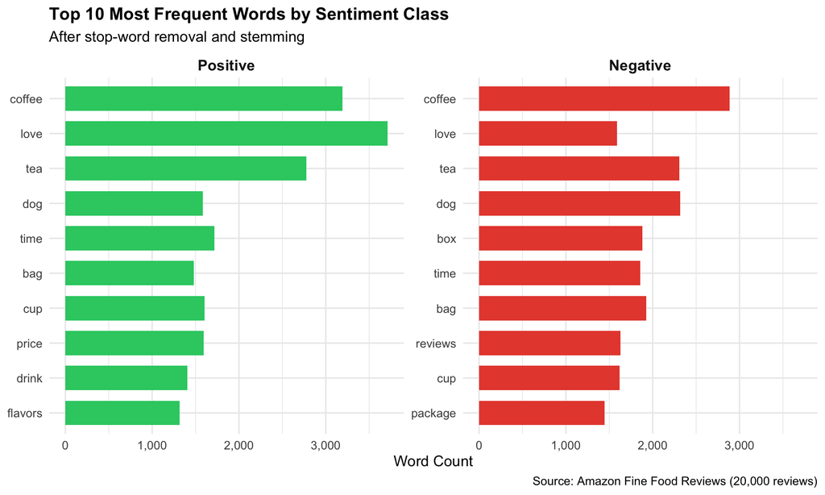

```r
pal <- c("Positive"="#2ECC71","Negative"="#E74C3C")

stem_label <- tokens %>%
  count(word_stem, word, sort=TRUE) %>%
  group_by(word_stem) %>% slice_max(n, n=1) %>% ungroup() %>%
  select(word_stem, display=word)

top_words <- tokens %>%
  count(class, word_stem, sort=TRUE) %>%
  group_by(class) %>% slice_max(n, n=10) %>% ungroup() %>%
  left_join(stem_label, by="word_stem") %>%
  mutate(display=fct_reorder(display, n))

ggplot(top_words, aes(x=display, y=n, fill=class)) +
  geom_col(show.legend=FALSE, width=0.7) +
  facet_wrap(~class, scales="free_y") +
  scale_fill_manual(values=pal) +
  scale_y_continuous(labels=comma) + coord_flip() +
  labs(title="Top 10 Most Frequent Words by Sentiment Class",
       subtitle="After stop-word removal and stemming",
       x=NULL, y="Word Count",
       caption="Source: Amazon Fine Food Reviews (20,000 reviews)") +
  theme_minimal(base_size=13) +
  theme(strip.text=element_text(face="bold",size=13),
        plot.title=element_text(face="bold",size=15))
```

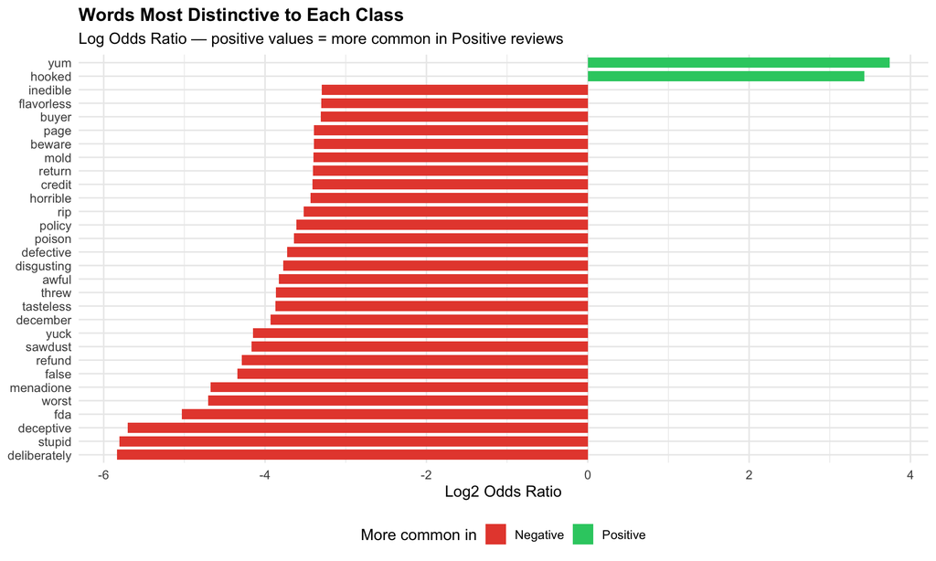

```r
word_ratio <- tokens %>%
  count(class, word_stem) %>%
  pivot_wider(names_from=class, values_from=n, values_fill=1) %>%
  mutate(total=Positive+Negative, log_or=log2(Positive/Negative)) %>%
  filter(total > 50) %>%
  left_join(stem_label, by="word_stem") %>%
  slice_max(abs(log_or), n=30) %>%
  mutate(display=fct_reorder(display, log_or),
         direction=ifelse(log_or>0,"Positive","Negative"))

ggplot(word_ratio, aes(x=display, y=log_or, fill=direction)) +
  geom_col(width=0.75) +
  scale_fill_manual(values=pal) + coord_flip() +
  labs(title="Words Most Distinctive to Each Class",
       subtitle="Log Odds Ratio — positive values = more common in Positive reviews",
       x=NULL, y="Log2 Odds Ratio", fill="More common in") +
  theme_minimal(base_size=12) +
  theme(legend.position="bottom", plot.title=element_text(face="bold",size=14))
```

# 5 Step 4: Word Clouds

## 5.1 Positive Reviews

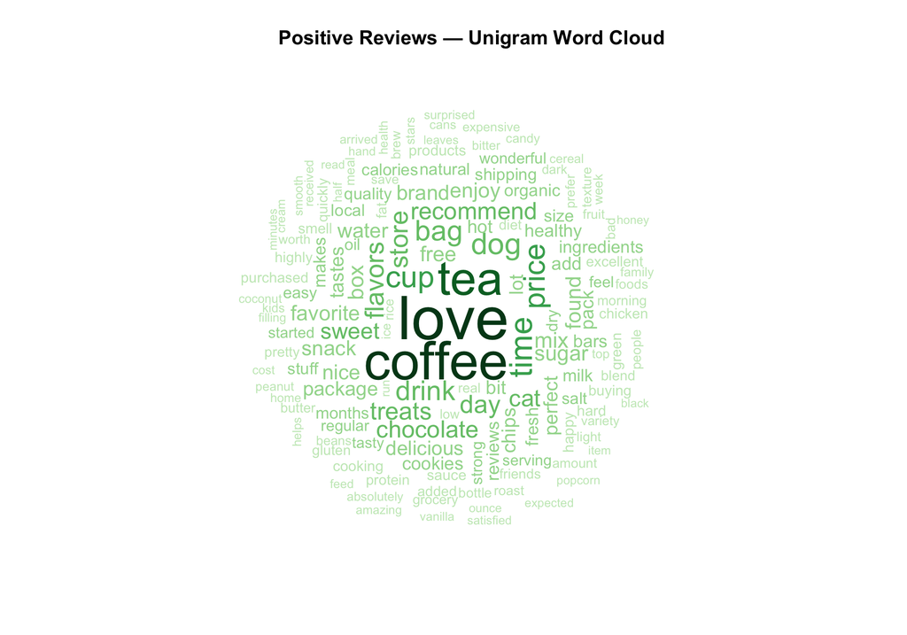

```r
pos_freq <- tokens %>% filter(class=="Positive") %>%
  count(word_stem, sort=TRUE) %>%
  left_join(stem_label, by="word_stem") %>% filter(!is.na(display))
set.seed(42)
wordcloud(pos_freq$display, pos_freq$n, max.words=150, random.order=FALSE,
          rot.per=0.2, colors=brewer.pal(9,"Greens")[3:9], scale=c(4,0.5))
title("Positive Reviews — Unigram Word Cloud", cex.main=1.3)
```

## 5.2 Negative Reviews

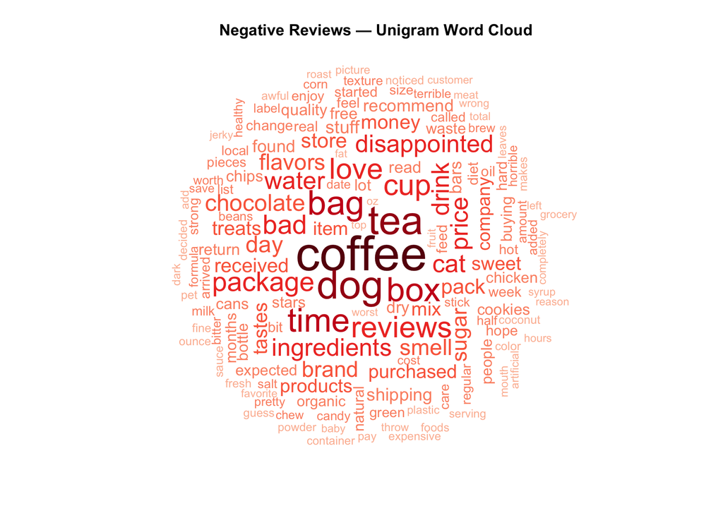

```r
neg_freq <- tokens %>% filter(class=="Negative") %>%
  count(word_stem, sort=TRUE) %>%
  left_join(stem_label, by="word_stem")
set.seed(42)
wordcloud(neg_freq$display, neg_freq$n, max.words=150, random.order=FALSE,
          rot.per=0.2, colors=brewer.pal(9,"Reds")[3:9], scale=c(4,0.5))
title("Negative Reviews — Unigram Word Cloud", cex.main=1.3)
```

## 5.3 Comparison Cloud

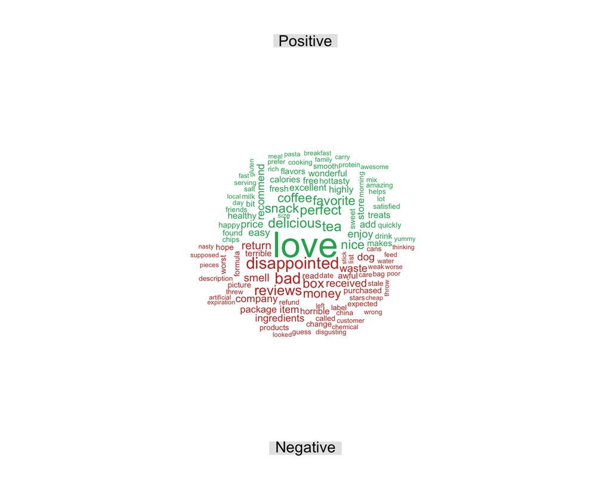

```r
comp_matrix <- tokens %>%
  count(class, word_stem) %>%
  left_join(stem_label, by="word_stem") %>% filter(!is.na(display)) %>%
  pivot_wider(id_cols=display, names_from=class, values_from=n, values_fill=0) %>%
  column_to_rownames("display") %>% as.matrix()
set.seed(42)
comparison.cloud(comp_matrix, max.words=120, colors=c("#27AE60","#C0392B"),
                 title.size=1.5, scale=c(3.5,0.4))
```

## 5.4 Bi-gram Clouds

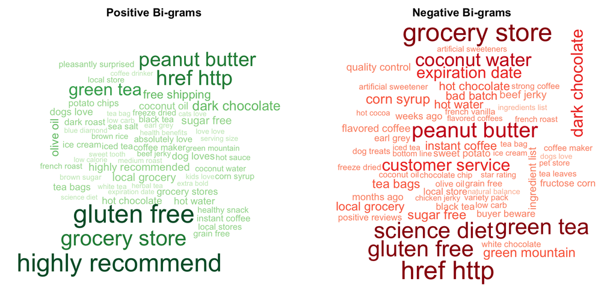

```r
bg_pos <- bigrams %>% filter(class=="Positive") %>% count(bigram, sort=TRUE) %>% filter(n>=10)
bg_neg <- bigrams %>% filter(class=="Negative") %>% count(bigram, sort=TRUE) %>% filter(n>=10)
par(mfrow=c(1,2), mar=c(1,1,2,1))
set.seed(42)
wordcloud(bg_pos$bigram, bg_pos$n, max.words=60, colors=brewer.pal(8,"Greens")[3:8], scale=c(2.5,0.4))
title("Positive Bi-grams", cex.main=1.1)
wordcloud(bg_neg$bigram, bg_neg$n, max.words=60, colors=brewer.pal(8,"Reds")[3:8], scale=c(2.5,0.4))
title("Negative Bi-grams", cex.main=1.1)
```

```r
par(mfrow=c(1,1))
```

# 6 Step 5: Word Co-occurrence Networks

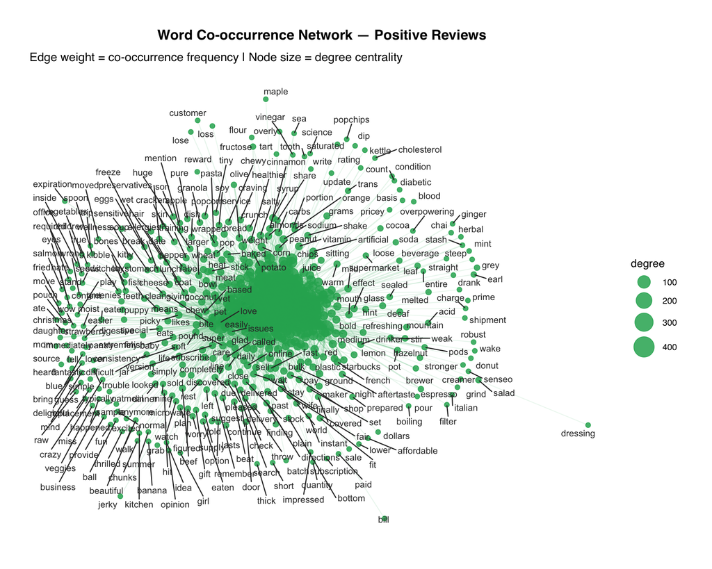

```r
build_network <- function(class_name, min_n=15) {
  tokens %>% filter(class==class_name) %>%
    group_by(Review_ID) %>% filter(n()>=3) %>% ungroup() %>%
    pairwise_count(word_stem, Review_ID, sort=TRUE, upper=FALSE) %>%
    filter(n>=min_n) %>%
    left_join(stem_label, by=c("item1"="word_stem")) %>% rename(label1=display) %>%
    left_join(stem_label, by=c("item2"="word_stem")) %>% rename(label2=display)
}

plot_network <- function(net, color, title) {
  g <- net %>% filter(!is.na(label1),!is.na(label2)) %>%
    select(label1, label2, n) %>% graph_from_data_frame(directed=FALSE)
  V(g)$degree <- degree(g)
  set.seed(2024)
  ggraph(g, layout="fr") +
    geom_edge_link(aes(edge_alpha=n, edge_width=n), color=color, show.legend=FALSE) +
    geom_node_point(aes(size=degree), color=color, alpha=0.85) +
    geom_node_text(aes(label=name), repel=TRUE, size=3.2,
                   color="grey20", max.overlaps=20) +
    scale_edge_width(range=c(0.4,2.5)) + scale_size(range=c(2,10)) +
    labs(title=title,
         subtitle="Edge weight = co-occurrence frequency | Node size = degree centrality") +
    theme_graph(base_family="sans") +
    theme(plot.title=element_text(face="bold",size=14,hjust=0.5))
}

plot_network(build_network("Positive", min_n=30), "#27AE60",
             "Word Co-occurrence Network — Positive Reviews")
```

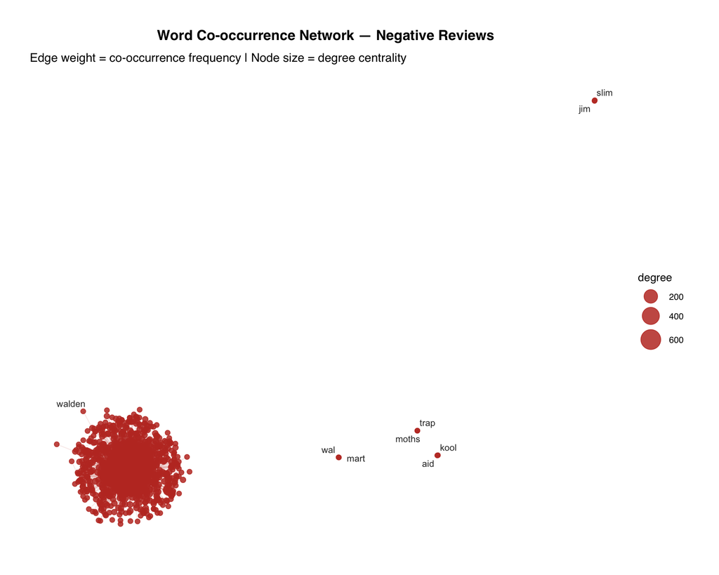

```r
plot_network(build_network("Negative", min_n=15), "#C0392B",
             "Word Co-occurrence Network — Negative Reviews")
```

# 7 Step 6: Sentiment Analysis

```r
afinn <- get_sentiments("afinn")

review_sentiment <- tokens %>%
  inner_join(afinn, by="word") %>%
  group_by(Review_ID, class) %>%
  summarise(sentiment=sum(value), word_count=n(), .groups="drop") %>%
  mutate(sentiment_norm=sentiment/word_count)

review_sentiment %>%
  group_by(class) %>%
  summarise(mean=round(mean(sentiment_norm,na.rm=TRUE),3),
            median=round(median(sentiment_norm,na.rm=TRUE),3),
            sd=round(sd(sentiment_norm,na.rm=TRUE),3), n=n()) %>%
  kbl(caption="Normalised AFINN Sentiment Scores by Class") %>%
  kable_styling(bootstrap_options=c("striped","hover"), full_width=FALSE)
```

Normalised AFINN Sentiment Scores by Class

| class | mean | median | sd | n |
| --- | --- | --- | --- | --- |
| Positive | 1.432 | 1.667 | 1.328 | 8976 |
| Negative | -0.114 | 0.000 | 1.519 | 8979 |

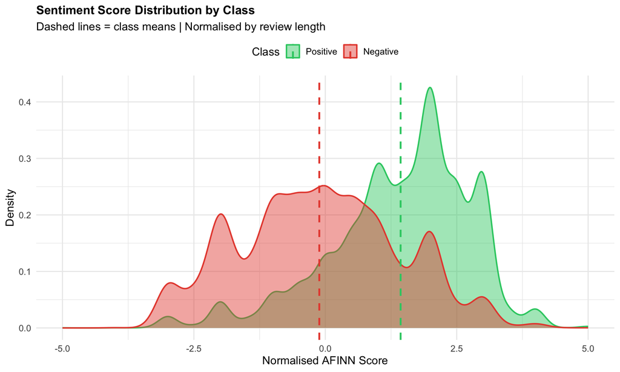

```r
means <- review_sentiment %>%
  group_by(class) %>% summarise(m=mean(sentiment_norm, na.rm=TRUE))

ggplot(review_sentiment, aes(x=sentiment_norm, fill=class, color=class)) +
  geom_density(alpha=0.45, size=0.8) +
  geom_vline(data=means, aes(xintercept=m, color=class), linetype="dashed", size=1) +
  scale_fill_manual(values=pal) + scale_color_manual(values=pal) +
  labs(title="Sentiment Score Distribution by Class",
       subtitle="Dashed lines = class means | Normalised by review length",
       x="Normalised AFINN Score", y="Density", fill="Class", color="Class") +
  theme_minimal(base_size=13) +
  theme(legend.position="top", plot.title=element_text(face="bold",size=14))
```

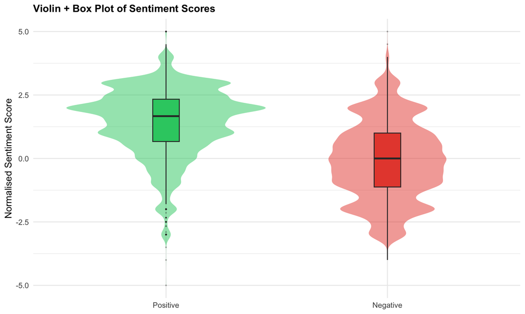

```r
ggplot(review_sentiment, aes(x=class, y=sentiment_norm, fill=class)) +
  geom_violin(alpha=0.5, color=NA) +
  geom_boxplot(width=0.12, outlier.size=0.4, outlier.alpha=0.3) +
  scale_fill_manual(values=pal) +
  labs(title="Violin + Box Plot of Sentiment Scores",
       x=NULL, y="Normalised Sentiment Score") +
  theme_minimal(base_size=13) +
  theme(legend.position="none", plot.title=element_text(face="bold",size=14))
```

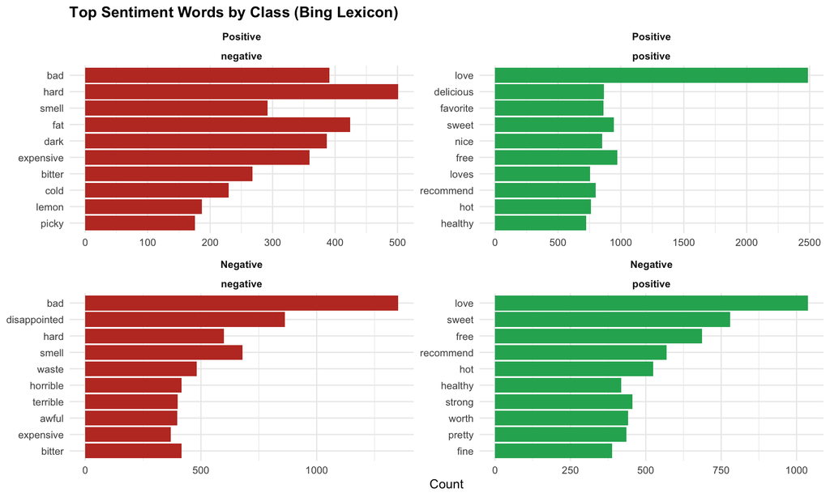

```r
get_sentiments("bing") %>%
  { inner_join(tokens, ., by="word") } %>%
  count(class, sentiment, word) %>%
  group_by(class, sentiment) %>% slice_max(n, n=10) %>% ungroup() %>%
  mutate(word=fct_reorder(word,n)) %>%
  ggplot(aes(x=word, y=n, fill=sentiment)) +
  geom_col(show.legend=FALSE) +
  facet_wrap(class~sentiment, scales="free", nrow=2) +
  scale_fill_manual(values=c("positive"="#27AE60","negative"="#C0392B")) +
  coord_flip() +
  labs(title="Top Sentiment Words by Class (Bing Lexicon)", x=NULL, y="Count") +
  theme_minimal(base_size=11) +
  theme(plot.title=element_text(face="bold",size=13),
        strip.text=element_text(face="bold"))
```